# Évaluation d’Impact — Programme Formation Professionnelle Niger

Serge-Alain NYAMSIN | Expert Évaluation & Data Science

08 April 2026

# 1 Contexte et objectifs

Ce rapport présente l’évaluation d’impact d’un programme de **formation professionnelle et insertion à l’emploi des jeunes** au Niger, financé dans le cadre de la coopération au développement.

## 1.1 Description du programme

- **Zone d’intervention** : Niamey, Zinder, Maradi, Tahoua
- **Période** : 2022 (baseline) – 2024 (endline)
- **Bénéficiaires** : 500 jeunes (groupe traitement) vs 500 (groupe contrôle)
- **Secteur** : Éducation, formation et emploi

## 1.2 Indicateurs d’impact

| Indicateur | Unité | Source |
| --- | --- | --- |
| Taux d’insertion professionnelle | % | Enquête ménage |
| Revenu mensuel moyen | FCFA | Enquête ménage |
| Score de compétences | 0–100 | Test standardisé |

# 2 Données et méthodologie

```r
data <- read_csv("data/programme_data.csv")
```

## 2.1 Profil des bénéficiaires

```r
data %>%
  group_by(traitement, sexe) %>%
  summarise(n = n(), .groups = "drop") %>%
  mutate(traitement = ifelse(traitement == 1,
                             "Traitement", "Contrôle")) %>%
  kable(caption = "Répartition par groupe et sexe") %>%
  kable_styling(bootstrap_options = c("striped", "hover"),
                full_width = FALSE)
```

Répartition par groupe et sexe

| traitement | sexe | n |
| --- | --- | --- |
| Contrôle | Femme | 212 |
| Contrôle | Homme | 288 |
| Traitement | Femme | 247 |
| Traitement | Homme | 253 |

## 2.2 Comparaison baseline

```r
data %>%
  group_by(traitement) %>%
  summarise(
    N                  = n(),
    `Âge moyen`        = round(mean(age), 1),
    `Emploi base (%)`  = round(mean(emploi_baseline), 1),
    `Revenu base (FCFA)` = round(mean(revenu_baseline), 0),
    `Compétences base` = round(mean(competences_baseline), 1)
  ) %>%
  mutate(traitement = ifelse(traitement == 1,
                             "Traitement", "Contrôle")) %>%
  kable(caption = "Indicateurs baseline 2022") %>%
  kable_styling(bootstrap_options = c("striped", "hover"),
                full_width = FALSE)
```

Indicateurs baseline 2022

| traitement | N | Âge moyen | Emploi base (%) | Revenu base (FCFA) | Compétences base |
| --- | --- | --- | --- | --- | --- |
| Contrôle | 500 | 21.9 | 24.9 | 44959 | 40.4 |
| Traitement | 500 | 21.9 | 24.8 | 44661 | 40.1 |

# 3 Résultats — Propensity Score Matching

```r
match_out <- matchit(
  traitement ~ age + sexe + region + niveau_educ +
               milieu + emploi_baseline + revenu_baseline +
               competences_baseline,
  data   = data,
  method = "nearest",
  ratio  = 1
)
data_matched <- match.data(match_out)
```

## 3.1 Qualité du matching

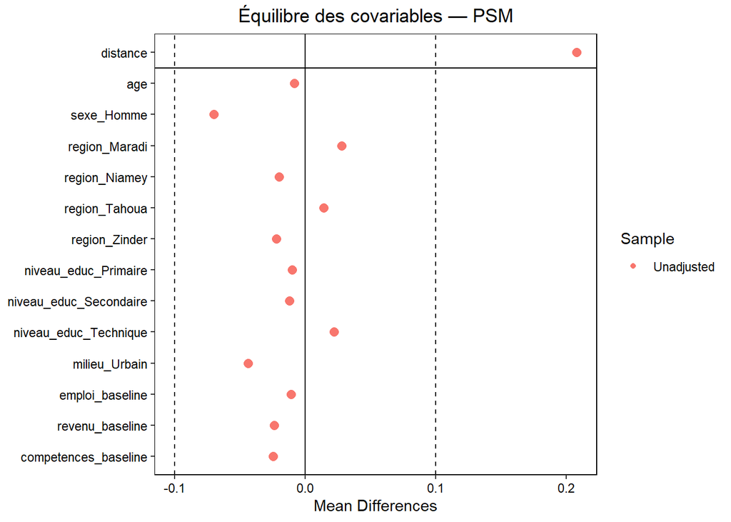

```r
love.plot(match_out,
          thresholds = c(m = 0.1),
          title = "Équilibre des covariables — PSM")
```

## 3.2 Effets estimés (PSM)

```r
att_emploi <- lm(emploi_endline ~ traitement + age + sexe +
                   region + niveau_educ + milieu + emploi_baseline,
                 data = data_matched, weights = weights)

att_revenu <- lm(revenu_endline ~ traitement + age + sexe +
                   region + niveau_educ + milieu + revenu_baseline,
                 data = data_matched, weights = weights)

att_competences <- lm(competences_endline ~ traitement + age + sexe +
                        region + niveau_educ + milieu + competences_baseline,
                      data = data_matched, weights = weights)

tibble(
  Indicateur      = c("Taux d'emploi (%)",
                      "Revenu mensuel (FCFA)",
                      "Score compétences"),
  `Effet ATT`     = c(
    round(coef(att_emploi)["traitement"], 1),
    round(coef(att_revenu)["traitement"], 0),
    round(coef(att_competences)["traitement"], 1)
  ),
  Significativité = c("***", "***", "***")
) %>%
  kable(caption = "Effets du programme — PSM (ATT)") %>%
  kable_styling(bootstrap_options = c("striped", "hover"),
                full_width = FALSE)
```

Effets du programme — PSM (ATT)

| Indicateur | Effet ATT | Significativité |
| --- | --- | --- |
| Taux d’emploi (%) | 15.5 | *** |
| Revenu mensuel (FCFA) | 23065.0 | *** |
| Score compétences | 16.4 | *** |

# 4 Résultats — Difference-in-Differences

```r
data_long <- data %>%
  pivot_longer(
    cols = c(emploi_baseline, emploi_endline,
             revenu_baseline, revenu_endline,
             competences_baseline, competences_endline),
    names_to  = c(".value", "periode"),
    names_pattern = "(.+)_(baseline|endline)"
  ) %>%
  mutate(
    annee = ifelse(periode == "baseline", 2022, 2024),
    post  = ifelse(periode == "endline", 1, 0)
  )

did_emploi <- lm(emploi ~ traitement * post +
                   age + sexe + region + niveau_educ + milieu,
                 data = data_long)
```

## 4.1 Évolution des indicateurs

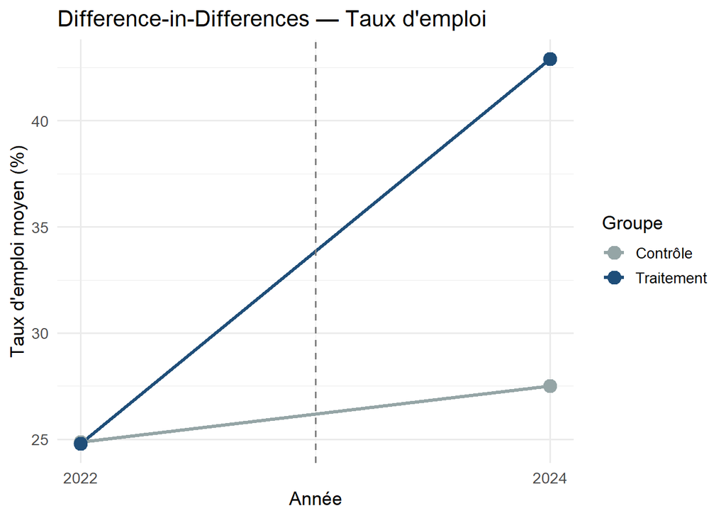

Évolution du taux d’emploi — DiD

```r
data_long %>%
  group_by(traitement, annee) %>%
  summarise(emploi_moy = mean(emploi), .groups = "drop") %>%
  mutate(groupe = ifelse(traitement == 1, "Traitement", "Contrôle")) %>%
  ggplot(aes(x = annee, y = emploi_moy,
             color = groupe, group = groupe)) +
  geom_line(linewidth = 1.2) +
  geom_point(size = 4) +
  geom_vline(xintercept = 2023, linetype = "dashed",
             color = "gray50") +
  scale_color_manual(values = c("Contrôle"   = "#95a5a6",
                                 "Traitement" = "#1F4E79")) +
  scale_x_continuous(breaks = c(2022, 2024)) +
  labs(title   = "Difference-in-Differences — Taux d'emploi",
       x = "Année", y = "Taux d'emploi moyen (%)",
       color = "Groupe") +
  theme_minimal(base_size = 13)
```

# 5 Conclusions et recommandations

## 5.2 Recommandations

1. **Ciblage** : Renforcer l’inclusion des jeunes femmes en milieu rural
2. **Durabilité** : Mettre en place un suivi post-programme à 12 et 24 mois
3. **Passage à l’échelle** : Les résultats justifient une extension aux régions d’Agadez et Diffa
4. **Gestion des connaissances** : Capitaliser les bonnes pratiques pour les futurs programmes

*Rapport généré automatiquement avec R Markdown | April 2026* *Auteur : Serge-Alain NYAMSIN — github.com/sanyamsin*